# Estimating varroa recombination rate

Nurit Eliash

2022-08-01

## load libraries

```r
library("tidyverse")
library("plyr")
library("dplyr")
library("ggplot2")
library("scales")
library("ggpubr")
library("gridExtra")
library("grid")
library("GGally")
library("vcfR") # for extracting genotype data from a vcf file
library("data.table")
library("stringr")
library("janitor")
knitr::opts_chunk$set(echo = TRUE)
```

## Load Variant Call Format (VCF) file.

Extract genotypes for each site and individual. The metadata for all samples can be found in [here](https://github.com/nurit-eliash/varroa-linkage-map/blob/main/data/meta_data_223.xlsx).

```r
vcf <- read.vcfR("/Users/nuriteliash/Documents/GitHub/varroa-linkage-map/data/vcf_filter/Q40BIALLDP16HDP40mis.5Chr7/Q40BIALLDP16HDP40mis.5Chr7.recode.vcf", verbose = FALSE )
vcf
```

```
## ***** Object of Class vcfR *****
## 223 samples
## 7 CHROMs
## 35,169 variants
## Object size: 293.5 Mb
## 0 percent missing data
## *****        *****         *****
```

```r
# extract the genotype for each site in each individual
gt <- extract.gt(vcf, element = "GT")
gt <- as.data.frame(t(gt)) %>%
  rownames_to_column("ID")
#clean the ID names
gt$ID <- sub("_[^_]+$", "", gt$ID)
```

We used the VCF file in two methods to estimate varroa mite recombination frequency:  
- **Lep-MAP3, a linkage mapping software (Rastas 2017).** script available in lep-MAP3-varroa.Rmd - **Manual estimation of the recombination rate**

Here we show how to calculate the recombination rate from a VCF file:

# Manual estimation of the recombination rate

See flowchart in Fig 1:

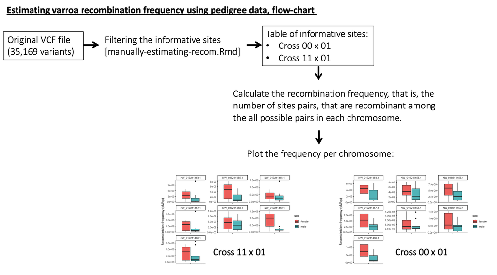

Count the sites with each genotype in each family, per chromosome.  
The counts must be per chromosome, as recombination can occur only between sites on the same chromosome.